# BMS353 - Week 1

November 2020

## Welcome and About me

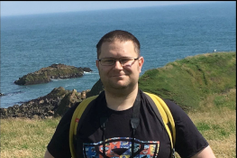

- Dr. Mark Dunning - Module Coordinator
  - sbc.shef.ac.uk/team/mark
- Bsc and Msc; Maths and Computer Science - York
- PhD Bioinformatics; - Cambridge
- Bioinformatics Core Analyst and Trainer; Cancer Research Uk
- Bioinformatics Core Lead; Sheffield

## Course Materials

- Course Website
  - https://sbc.shef.ac.uk/bms353
- Video recordings via blackboard
- Pre-materials each week

## Teaching format

- Short intro lecture and pre-material videos
- Live online sessions with module coordinator and demonstrators
  - working through RStudio code and solving problems
  - small breakout groups with demonstrators to answer questions
- Solutions available to check your work
- Assignment at the end
  - analysis of a real-life dataset

## Course Aims

- *make students aware of effects of experimental design*
- *good understanding of technologies and methods for Bioinformatics*
- *introduce basic coding in R*

## Course Aims - specifics

- Walk through RNA-seq workflow in R
  - quality assessment
  - differential expression
  - visualisation
  - downstream analysis
- By the end you should have a reproducible report for the above analysis

## Course Aims - high-level

- Creating reproducible reports
  - not just showing the answer - but how you got to it
- Getting stuck, and figuring out how to solve errors
- Interpreting and questioning data

## Prior knowledge

- Rstudio and the tidyverse packages
  - dplyr
  - ggplot2
- RNA-seq workflow
  - in Galaxy
- sbc.shef.ac.uk/bms397

## Why R?

- Reputation
- Interactivity
- Flexibility
- Support
- **Reproducibility**

## Reproducibility

[figure not shown]

## Week 1

- Recap on RStudio and how to make reproducible reports
- Introduce the resources available through Bioconductor
- Setup software and data for the rest of the course

## RStudio recap

- Various reporting and documenting formats
  - the Terminal
  - R script
  - R markdown
  - R notebook
- Discuss merit of each format

## Bioconductor

> committed to open source, collaborative, distributed software and literate, reproducible research. Enabling user and developer communities is an essential part of our mission
- Software packages
- Example datasets
- Workflows and documentation
- Support forum

## Other viewing

- [A non reproducible workflow](https://youtu.be/s3JldKoA0zw) - 2 minutes
- [Bioconductor introduction](https://youtu.be/dg6NvmMVQ3I) - 5 minutes
- [A tour of the Bioconductor website](https://www.youtube.com/watch?v=HgbnSMiqlOg) - 5 minutes
- [The importance of reproducibility in high-throughput Biology](https://youtu.be/7gYIs7uYbMo) - 37 minutes